# PCA Analysis

# Incluir librerias

```r
library(readxl)
library(tidyverse)
```

```r
library(ggplot2)
```

# Analisis de Componentes principales en R

Este tipo de análisis se hace para extraer información importante de una tabla de datos multivariable así como para reducir la información mediante la identificación de una combinación lineal de las variables originales. El método PCA es especialmente útil cuando las variables del conjunto de datos están muy correlacionadas para reducir la redundancia.

## Estandarización de los datos

PCA funciona mejor con variables numéricas. Si nuestras variables se miden en diferentes escalas (eg: metros, kgs, ect..) es recomendable estandarizarlas. Lo normal es ecalarlas para que tengar desviación estándar uno y media cero.

```
##       mpg             cyl             disp             hp
##  Min.   :10.40   Min.   :4.000   Min.   : 71.1   Min.   : 52.0
##  1st Qu.:15.43   1st Qu.:4.000   1st Qu.:120.8   1st Qu.: 96.5
##  Median :19.20   Median :6.000   Median :196.3   Median :123.0
##  Mean   :20.09   Mean   :6.188   Mean   :230.7   Mean   :146.7
##  3rd Qu.:22.80   3rd Qu.:8.000   3rd Qu.:326.0   3rd Qu.:180.0
##  Max.   :33.90   Max.   :8.000   Max.   :472.0   Max.   :335.0
##       drat             wt             qsec             vs
##  Min.   :2.760   Min.   :1.513   Min.   :14.50   Min.   :0.0000
##  1st Qu.:3.080   1st Qu.:2.581   1st Qu.:16.89   1st Qu.:0.0000
##  Median :3.695   Median :3.325   Median :17.71   Median :0.0000
##  Mean   :3.597   Mean   :3.217   Mean   :17.85   Mean   :0.4375
##  3rd Qu.:3.920   3rd Qu.:3.610   3rd Qu.:18.90   3rd Qu.:1.0000
##  Max.   :4.930   Max.   :5.424   Max.   :22.90   Max.   :1.0000
##        am              gear            carb
##  Min.   :0.0000   Min.   :3.000   Min.   :1.000
##  1st Qu.:0.0000   1st Qu.:3.000   1st Qu.:2.000
##  Median :0.0000   Median :4.000   Median :2.000
##  Mean   :0.4062   Mean   :3.688   Mean   :2.812
##  3rd Qu.:1.0000   3rd Qu.:4.000   3rd Qu.:4.000
##  Max.   :1.0000   Max.   :5.000   Max.   :8.000
```

El objeto generado por PCA contiene toda la información necesaria para nuestro analisis.

```r
print(res.pca)
```

```
## **Results for the Principal Component Analysis (PCA)**
## The analysis was performed on 32 individuals, described by 9 variables
## *The results are available in the following objects:
##
##    name               description
## 1  "$eig"             "eigenvalues"
## 2  "$var"             "results for the variables"
## 3  "$var$coord"       "coord. for the variables"
## 4  "$var$cor"         "correlations variables - dimensions"
## 5  "$var$cos2"        "cos2 for the variables"
## 6  "$var$contrib"     "contributions of the variables"
## 7  "$ind"             "results for the individuals"
## 8  "$ind$coord"       "coord. for the individuals"
## 9  "$ind$cos2"        "cos2 for the individuals"
## 10 "$ind$contrib"     "contributions of the individuals"
## 11 "$call"            "summary statistics"
## 12 "$call$centre"     "mean of the variables"
## 13 "$call$ecart.type" "standard error of the variables"
## 14 "$call$row.w"      "weights for the individuals"
## 15 "$call$col.w"      "weights for the variables"
```

## Eigenvalues y Varianzas

- eigenvalues: miden la cantidad de variación retenida por cada componente principal (PC). Las primeras componentes se corresponden con las direcciones que tienen la máxima cantidad de variación en el conjunto de datos.

Estos eigenvalues son los valores que nos indican cuantas componentes principales necesitamos tener en consideración.

Para acceder a esa información:

```r
eig.val <- get_eigenvalue(res.pca)
eig.val
```

```
##       eigenvalue variance.percent cumulative.variance.percent
## Dim.1 5.65593947       62.8437719                    62.84377
## Dim.2 2.08210029       23.1344477                    85.97822
## Dim.3 0.50421482        5.6023869                    91.58061
## Dim.4 0.26502753        2.9447503                    94.52536
## Dim.5 0.18315864        2.0350960                    96.56045
## Dim.6 0.12379319        1.3754799                    97.93593
## Dim.7 0.10506192        1.1673547                    99.10329
## Dim.8 0.05851375        0.6501528                    99.75344
## Dim.9 0.02219038        0.2465598                   100.00000
```

Como veis un valor de eigenvalue > 1 indica que esa PC explican más varianza que la explicada sólo por una de las variables originales en los datos estandarizados.

En este ejemplo sólo tendríamos en consideración las dos primeras componentes que además explican mas de un 85% de la variabilidad de la muestra ellas solas.

Para ver estos datos de una forma mas visual podemos utilizar factorextra

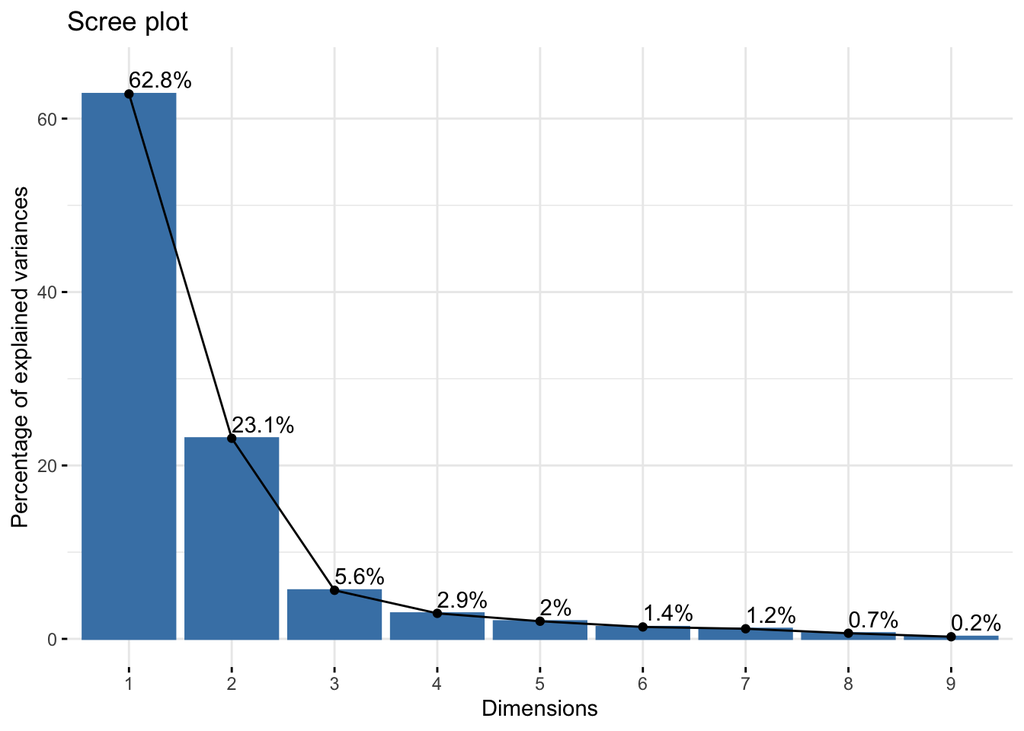

```r
fviz_eig(res.pca, addlabels = TRUE, ylim = c(0, 65))
```

Este gráfico nos explica cuanta varianza de la muestra explica cada dimensión.

## Obtención de las variables implicadas en cada PC

El objeto generado por PCA contiene todos los resultados de las variables activas (coordenadas, correlación entre variables y ejes, coseno cuadrado y contribuciones)

- var$cos2: representa la calidad de la representación de las variables en el mapa de factores.
- var$contrib: contiene el porcentaje de contribución de las variables a los componentes principales.
- Cos2: contiene la calidad del mapa de factores

Ejemplos de como acceder a dichos datos de forma individual:

## Correlación entre variables y componentes principales

La correlación entre una variable y un componente principal (PC) se utiliza como las coordenadas de la variable en la PC.

- Las variables que no se correlacionan con ninguna PC/Dim o que se correlacionan con las últimas dimensiones son variables con baja contribución y podrían ser eliminadas para simplificar el análisis general.

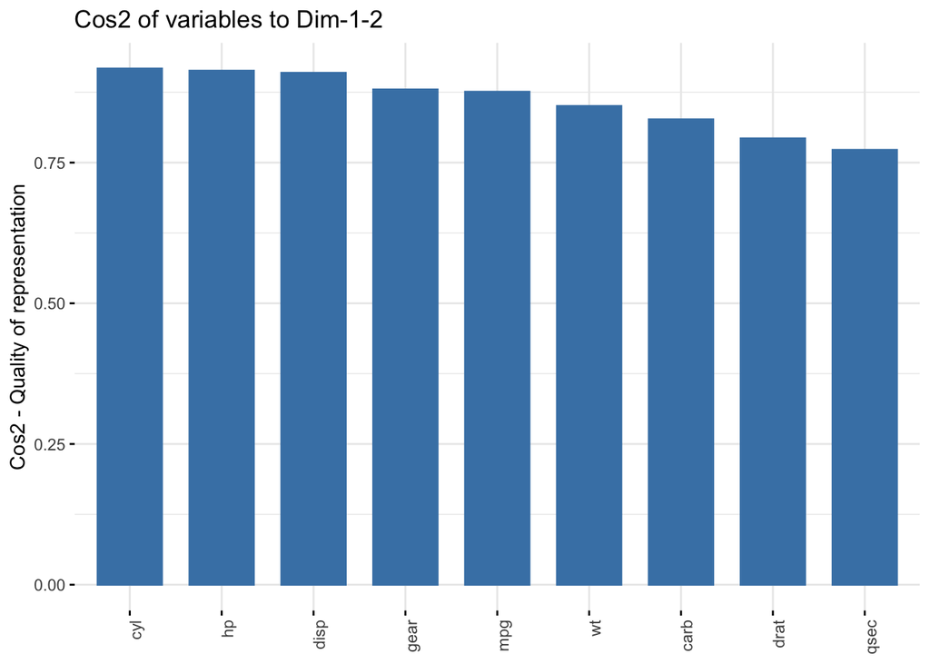

```r
# Total cos2 of variables on Dim.1 and Dim.2
fviz_cos2(res.pca, choice = "var", axes = 1:2,xtickslab.rt = 90,top=10)
```

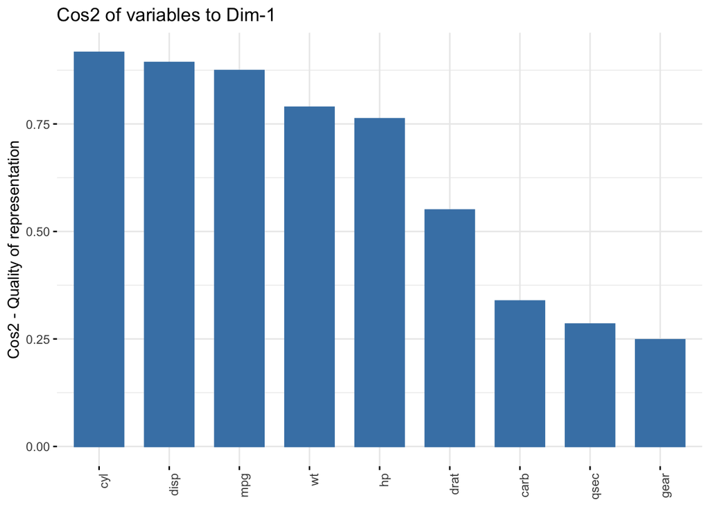

```r
fviz_cos2(res.pca, choice = "var", axes = 1,xtickslab.rt = 90,top=10)
```

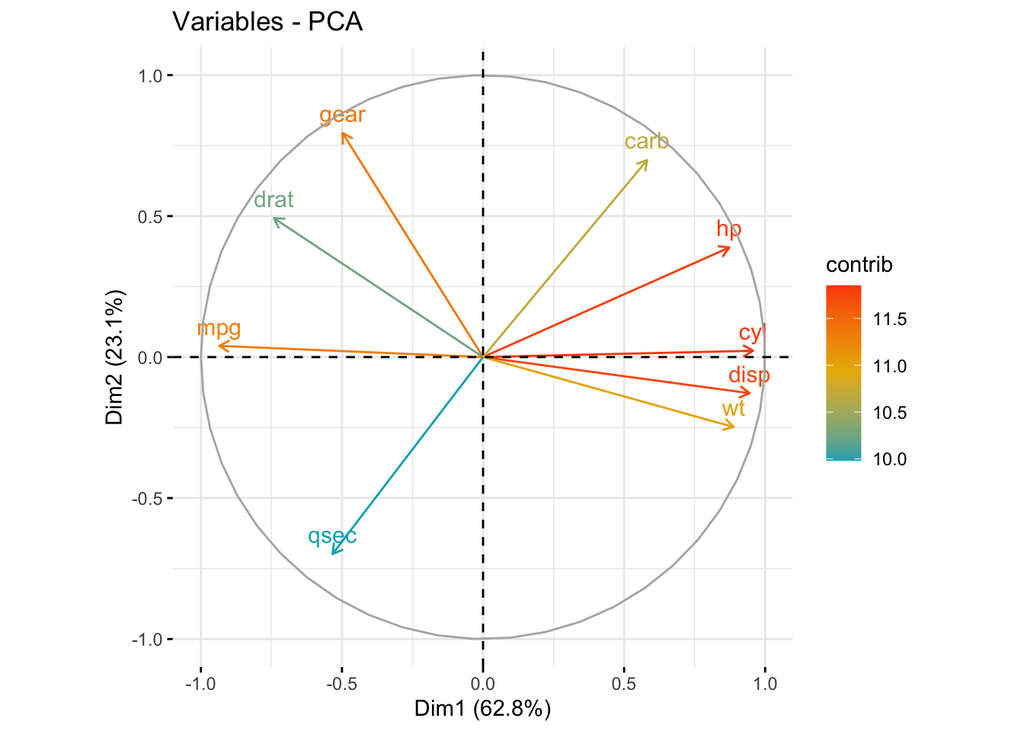

```r
fviz_pca_var(res.pca, col.var = "contrib",
             gradient.cols = c("#00AFBB", "#E7B800", "#FC4E07"))
```

## Que efecto tienen las diferentes observaciones

Los datos del objeto tienen todo lo necesario para visualizar la correlación entre los individuos y su contribución a las distintas dimensiones

```r
ind <- get_pca_ind(res.pca)
ind
```

```
## Principal Component Analysis Results for individuals
##  ===================================================
##   Name       Description
## 1 "$coord"   "Coordinates for the individuals"
## 2 "$cos2"    "Cos2 for the individuals"
## 3 "$contrib" "contributions of the individuals"
```

```r
# # Coordinates of individuals
# head(ind$coord)
# # Quality of individuals
head(ind$cos2)
```

```
##                          Dim.1      Dim.2       Dim.3       Dim.4        Dim.5
## Mazda RX4         0.1655951140 0.51682843 0.015668558 0.005960474 0.2122578503
## Mazda RX4 Wag     0.2004889547 0.47128283 0.006059642 0.003624690 0.2129413427
## Datsun 710        0.8841673131 0.01783127 0.007383043 0.001972604 0.0009713011
## Hornet 4 Drive    0.0109145870 0.92015811 0.025559927 0.022346500 0.0140094087
## Hornet Sportabout 0.5688193752 0.15511697 0.241006695 0.004906101 0.0112018813
## Valiant           0.0003571421 0.86884786 0.001813421 0.110248274 0.0022950676
##                         Dim.6        Dim.7        Dim.8        Dim.9
## Mazda RX4         0.005870970 0.0673404898 3.986866e-06 1.047413e-02
## Mazda RX4 Wag     0.002163633 0.0993237282 1.584301e-03 2.530881e-03
## Datsun 710        0.053733767 0.0249248308 6.823935e-03 2.191935e-03
## Hornet 4 Drive    0.001654524 0.0002563259 1.324178e-04 4.968202e-03
## Hornet Sportabout 0.007547581 0.0007581601 5.241763e-03 5.401477e-03
## Valiant           0.007706673 0.0073161034 1.412856e-03 2.601773e-06
```

```r
# # Contributions of individuals
# head(ind$contrib)
```

Igual que con las variables podemos colorear a los individuos en función de su ccontribución (cos2)

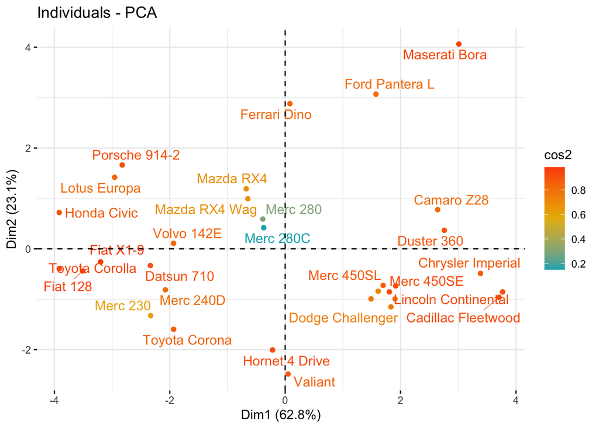

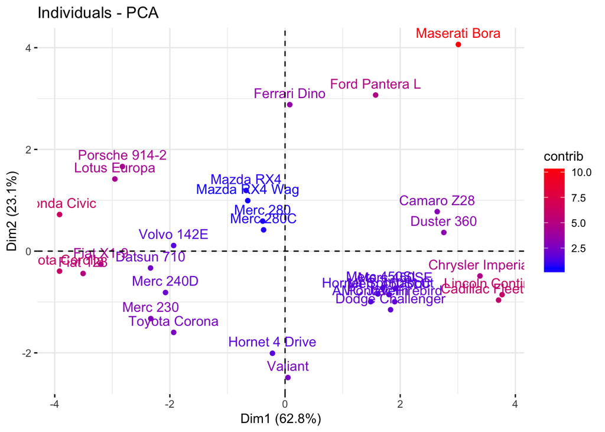

La contribución de cada uno de los individuos a las dos primeras dimensiones se puede visualizar de la siguiente manera

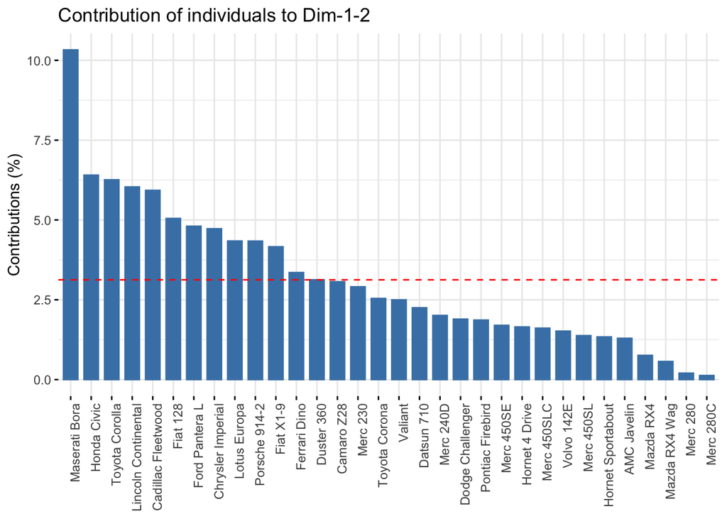

```r
# Total contribution on PC1 and PC2
fviz_contrib(res.pca, choice = "ind", axes = 1:2, xtickslab.rt = 90,top=50, )
```

Tambien poemos visualizar variables e individuos a la vez

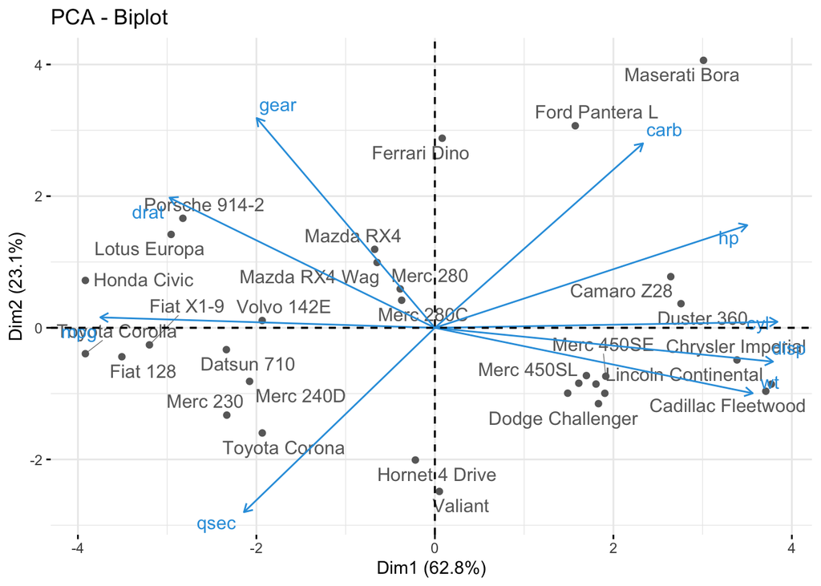

En datasets donde tenemos factores tambien podemos ver como esas dimensiones se relaccionan con los factoes. Un ejemplo simple aqui con el dataset iris

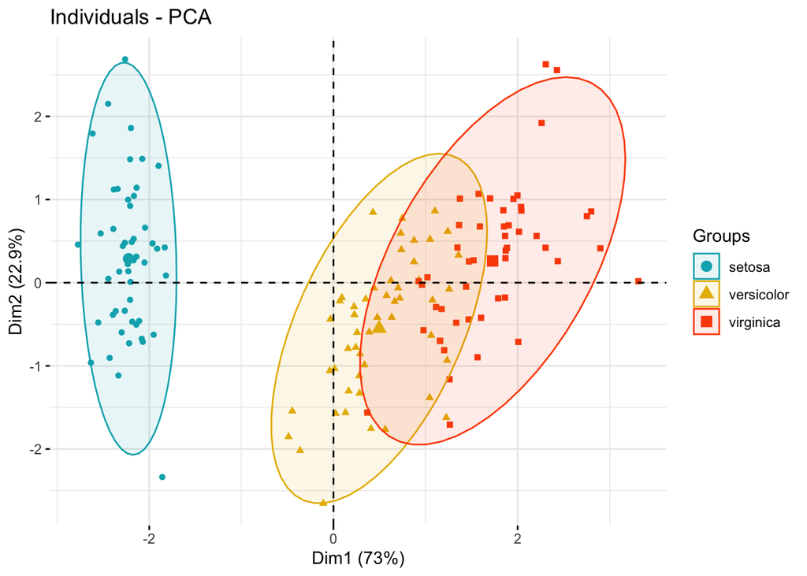

```r
# The variable Species (index = 5) is removed
# before PCA analysis
iris.pca <- PCA(iris[,-5], graph = FALSE)
fviz_pca_ind(iris.pca,
             geom.ind = "point", # show points only (nbut not "text")
             col.ind = iris$Species, # color by groups
             palette = c("#00AFBB", "#E7B800", "#FC4E07"),
             addEllipses = TRUE, # Concentration ellipses
             legend.title = "Groups"
             )
```